K-State Honor Code: "On my honor, as a student, I have neither given nor received unauthorized aid on this academic work."

# 1. What is the goal of correlation analysis?

### The Goal of correlation analysis is to mathematically determine the relationship between two or more variables. To see if a change to one of the variable correlates to a change in an outcome and how strong that change is.

## The characteristics of the people who are likely to experience “2nd heart attack”

```python
import pandas as pd
import numpy as np
import seaborn as sns
import matplotlib.pyplot as plt
%matplotlib inline
```

```python
df=pd.read_csv("data/Chapter09DataSet_Training.csv")
print df.head()
```

```
   Age  Marital_Status  Gender  Weight_Category  Cholesterol  \
0   60               2       0                1          150
1   69               2       1                1          170
2   52               1       0                0          174
3   66               2       1                1          169
4   70               3       0                1          237

   Stress_Management  Trait_Anxiety 2nd_Heart_Attack
0                  1             50              Yes
1                  0             60              Yes
2                  1             35               No
3                  0             60              Yes
4                  0             65              Yes
```

```python
df.info()
```

```
<class 'pandas.core.frame.DataFrame'>
RangeIndex: 138 entries, 0 to 137
Data columns (total 8 columns):
Age                  138 non-null int64
Marital_Status       138 non-null int64
Gender               138 non-null int64
Weight_Category      138 non-null int64
Cholesterol          138 non-null int64
Stress_Management    138 non-null int64
Trait_Anxiety        138 non-null int64
2nd_Heart_Attack     138 non-null object
dtypes: int64(7), object(1)
memory usage: 8.7+ KB
```

```python
df.isnull().sum()
```

```
Age                  0
Marital_Status       0
Gender               0
Weight_Category      0
Cholesterol          0
Stress_Management    0
Trait_Anxiety        0
2nd_Heart_Attack     0
dtype: int64
```

```python
df.groupby('Gender').size()
```

```
Gender
0    52
1    86
dtype: int64
```

```python
df.groupby('Gender').count()
```

| Gender | Age | Marital_Status | Weight_Category | Cholesterol | Stress_Management | Trait_Anxiety | 2nd_Heart_Attack |
| --- | --- | --- | --- | --- | --- | --- | --- |
| 0 | 52 | 52 | 52 | 52 | 52 | 52 | 52 |
| 1 | 86 | 86 | 86 | 86 | 86 | 86 | 86 |

```python
df.corr()
```

|  | Age | Marital_Status | Gender | Weight_Category | Cholesterol | Stress_Management | Trait_Anxiety |
| --- | --- | --- | --- | --- | --- | --- | --- |
| Age | 1.000000 | 0.427159 | 0.076195 | 0.402007 | 0.395331 | -0.359295 | 0.667169 |
| Marital_Status | 0.427159 | 1.000000 | -0.033225 | 0.065402 | 0.273574 | -0.291773 | 0.238340 |
| Gender | 0.076195 | -0.033225 | 1.000000 | 0.448531 | 0.191354 | -0.241320 | 0.082007 |
| Weight_Category | 0.402007 | 0.065402 | 0.448531 | 1.000000 | 0.397702 | -0.347322 | 0.501244 |
| Cholesterol | 0.395331 | 0.273574 | 0.191354 | 0.397702 | 1.000000 | -0.405735 | 0.579485 |
| Stress_Management | -0.359295 | -0.291773 | -0.241320 | -0.347322 | -0.405735 | 1.000000 | -0.321362 |
| Trait_Anxiety | 0.667169 | 0.238340 | 0.082007 | 0.501244 | 0.579485 | -0.321362 | 1.000000 |

```python
Married_dummies = pd.get_dummies(df['Marital_Status'], prefix = 'Marital_Status')
df = df.join(Married_dummies)
df.head()
```

|  | Age | Marital_Status | Gender | Weight_Category | Cholesterol | Stress_Management | Trait_Anxiety | 2nd_Heart_Attack | Marital_Status_0 | Marital_Status_1 | Marital_Status_2 | Marital_Status_3 |
| --- | --- | --- | --- | --- | --- | --- | --- | --- | --- | --- | --- | --- |
| 0 | 60 | 2 | 0 | 1 | 150 | 1 | 50 | Yes | 0 | 0 | 1 | 0 |
| 1 | 69 | 2 | 1 | 1 | 170 | 0 | 60 | Yes | 0 | 0 | 1 | 0 |
| 2 | 52 | 1 | 0 | 0 | 174 | 1 | 35 | No | 0 | 1 | 0 | 0 |
| 3 | 66 | 2 | 1 | 1 | 169 | 0 | 60 | Yes | 0 | 0 | 1 | 0 |
| 4 | 70 | 3 | 0 | 1 | 237 | 0 | 65 | Yes | 0 | 0 | 0 | 1 |

```python
sex_dummies = pd.get_dummies(df['Gender'], prefix = 'Gender')
df = df.join(sex_dummies)
df.head()
```

|  | Age | Marital_Status | Gender | Weight_Category | Cholesterol | Stress_Management | Trait_Anxiety | 2nd_Heart_Attack | Marital_Status_0 | Marital_Status_1 | Marital_Status_2 | Marital_Status_3 | Gender_0 | Gender_1 |
| --- | --- | --- | --- | --- | --- | --- | --- | --- | --- | --- | --- | --- | --- | --- |
| 0 | 60 | 2 | 0 | 1 | 150 | 1 | 50 | Yes | 0 | 0 | 1 | 0 | 1 | 0 |
| 1 | 69 | 2 | 1 | 1 | 170 | 0 | 60 | Yes | 0 | 0 | 1 | 0 | 0 | 1 |
| 2 | 52 | 1 | 0 | 0 | 174 | 1 | 35 | No | 0 | 1 | 0 | 0 | 1 | 0 |
| 3 | 66 | 2 | 1 | 1 | 169 | 0 | 60 | Yes | 0 | 0 | 1 | 0 | 0 | 1 |
| 4 | 70 | 3 | 0 | 1 | 237 | 0 | 65 | Yes | 0 | 0 | 0 | 1 | 1 | 0 |

```python
sex_dummies = pd.get_dummies(df['Gender'], prefix = 'Sex')
df = df.join(sex_dummies)
df.head()
```

|  | Age | Marital_Status | Gender | Weight_Category | Cholesterol | Stress_Management | Trait_Anxiety | 2nd_Heart_Attack | Marital_Status_0 | Marital_Status_1 | Marital_Status_2 | Marital_Status_3 | Gender_0 | Gender_1 | Sex_0 | Sex_1 |
| --- | --- | --- | --- | --- | --- | --- | --- | --- | --- | --- | --- | --- | --- | --- | --- | --- |
| 0 | 60 | 2 | 0 | 1 | 150 | 1 | 50 | Yes | 0 | 0 | 1 | 0 | 1 | 0 | 1 | 0 |
| 1 | 69 | 2 | 1 | 1 | 170 | 0 | 60 | Yes | 0 | 0 | 1 | 0 | 0 | 1 | 0 | 1 |
| 2 | 52 | 1 | 0 | 0 | 174 | 1 | 35 | No | 0 | 1 | 0 | 0 | 1 | 0 | 1 | 0 |
| 3 | 66 | 2 | 1 | 1 | 169 | 0 | 60 | Yes | 0 | 0 | 1 | 0 | 0 | 1 | 0 | 1 |
| 4 | 70 | 3 | 0 | 1 | 237 | 0 | 65 | Yes | 0 | 0 | 0 | 1 | 1 | 0 | 1 | 0 |

```python
df = df.replace({'2nd_Heart_Attack': {'Yes': 1, 'No': 0}})
df.head()
```

|  | Age | Marital_Status | Gender | Weight_Category | Cholesterol | Stress_Management | Trait_Anxiety | 2nd_Heart_Attack | Marital_Status_0 | Marital_Status_1 | Marital_Status_2 | Marital_Status_3 | Gender_0 | Gender_1 | Sex_0 | Sex_1 |
| --- | --- | --- | --- | --- | --- | --- | --- | --- | --- | --- | --- | --- | --- | --- | --- | --- |
| 0 | 60 | 2 | 0 | 1 | 150 | 1 | 50 | 1 | 0 | 0 | 1 | 0 | 1 | 0 | 1 | 0 |
| 1 | 69 | 2 | 1 | 1 | 170 | 0 | 60 | 1 | 0 | 0 | 1 | 0 | 0 | 1 | 0 | 1 |
| 2 | 52 | 1 | 0 | 0 | 174 | 1 | 35 | 0 | 0 | 1 | 0 | 0 | 1 | 0 | 1 | 0 |
| 3 | 66 | 2 | 1 | 1 | 169 | 0 | 60 | 1 | 0 | 0 | 1 | 0 | 0 | 1 | 0 | 1 |
| 4 | 70 | 3 | 0 | 1 | 237 | 0 | 65 | 1 | 0 | 0 | 0 | 1 | 1 | 0 | 1 | 0 |

```python
fat_dummies = pd.get_dummies(df['Weight_Category'], prefix = 'Weight')
df = df.join(fat_dummies)
df.head()
```

|  | Age | Marital_Status | Gender | Weight_Category | Cholesterol | Stress_Management | Trait_Anxiety | 2nd_Heart_Attack | Marital_Status_0 | Marital_Status_1 | Marital_Status_2 | Marital_Status_3 | Gender_0 | Gender_1 | Sex_0 | Sex_1 | Weight_0 | Weight_1 | Weight_2 |
| --- | --- | --- | --- | --- | --- | --- | --- | --- | --- | --- | --- | --- | --- | --- | --- | --- | --- | --- | --- |
| 0 | 60 | 2 | 0 | 1 | 150 | 1 | 50 | 1 | 0 | 0 | 1 | 0 | 1 | 0 | 1 | 0 | 0 | 1 | 0 |
| 1 | 69 | 2 | 1 | 1 | 170 | 0 | 60 | 1 | 0 | 0 | 1 | 0 | 0 | 1 | 0 | 1 | 0 | 1 | 0 |
| 2 | 52 | 1 | 0 | 0 | 174 | 1 | 35 | 0 | 0 | 1 | 0 | 0 | 1 | 0 | 1 | 0 | 1 | 0 | 0 |
| 3 | 66 | 2 | 1 | 1 | 169 | 0 | 60 | 1 | 0 | 0 | 1 | 0 | 0 | 1 | 0 | 1 | 0 | 1 | 0 |
| 4 | 70 | 3 | 0 | 1 | 237 | 0 | 65 | 1 | 0 | 0 | 0 | 1 | 1 | 0 | 1 | 0 | 0 | 1 | 0 |

```python
df= df.drop(['Gender', 'Marital_Status', 'Weight_Category'], axis = 1)
```

```python
df.corr()
```

|  | Age | Cholesterol | Stress_Management | Trait_Anxiety | 2nd_Heart_Attack | Marital_Status_0 | Marital_Status_1 | Marital_Status_2 | Marital_Status_3 | Gender_0 | Gender_1 | Sex_0 | Sex_1 | Weight_0 | Weight_1 | Weight_2 |
| --- | --- | --- | --- | --- | --- | --- | --- | --- | --- | --- | --- | --- | --- | --- | --- | --- |
| Age | 1.000000 | 0.395331 | -0.359295 | 0.667169 | 0.499182 | 0.000689 | -0.466092 | 0.196552 | 0.336010 | -0.076195 | 0.076195 | -0.076195 | 0.076195 | -0.502928 | 0.340887 | 0.159133 |
| Cholesterol | 0.395331 | 1.000000 | -0.405735 | 0.579485 | 0.506531 | -0.303985 | -0.065453 | 0.104248 | 0.135366 | -0.191354 | 0.191354 | -0.191354 | 0.191354 | -0.375862 | 0.104245 | 0.289266 |
| Stress_Management | -0.359295 | -0.405735 | 1.000000 | -0.321362 | -0.439473 | 0.278711 | 0.179056 | -0.260109 | -0.061928 | 0.241320 | -0.241320 | 0.241320 | -0.241320 | 0.299208 | -0.035432 | -0.284087 |
| Trait_Anxiety | 0.667169 | 0.579485 | -0.321362 | 1.000000 | 0.482548 | -0.109359 | -0.136640 | 0.024721 | 0.208677 | -0.082007 | 0.082007 | -0.082007 | 0.082007 | -0.448879 | 0.083823 | 0.391489 |
| 2nd_Heart_Attack | 0.499182 | 0.506531 | -0.439473 | 0.482548 | 1.000000 | -0.244500 | -0.441389 | 0.602321 | -0.069830 | -0.317746 | 0.317746 | -0.317746 | 0.317746 | -0.666185 | 0.144626 | 0.558125 |
| Marital_Status_0 | 0.000689 | -0.303985 | 0.278711 | -0.109359 | -0.244500 | 1.000000 | -0.186989 | -0.205003 | -0.113822 | -0.128907 | 0.128907 | -0.128907 | 0.128907 | -0.175412 | 0.295718 | -0.144607 |
| Marital_Status_1 | -0.466092 | -0.065453 | 0.179056 | -0.136640 | -0.441389 | -0.186989 | 1.000000 | -0.622918 | -0.345857 | 0.253841 | -0.253841 | 0.253841 | -0.253841 | 0.362441 | -0.295528 | -0.058252 |
| Marital_Status_2 | 0.196552 | 0.104248 | -0.260109 | 0.024721 | 0.602321 | -0.205003 | -0.622918 | 1.000000 | -0.379176 | -0.368523 | 0.368523 | -0.368523 | 0.368523 | -0.302609 | 0.026062 | 0.298377 |
| Marital_Status_3 | 0.336010 | 0.135366 | -0.061928 | 0.208677 | -0.069830 | -0.113822 | -0.345857 | -0.379176 | 1.000000 | 0.234997 | -0.234997 | 0.234997 | -0.234997 | 0.040555 | 0.158687 | -0.223525 |
| Gender_0 | -0.076195 | -0.191354 | 0.241320 | -0.082007 | -0.317746 | -0.128907 | 0.253841 | -0.368523 | 0.234997 | 1.000000 | -1.000000 | 1.000000 | -1.000000 | 0.465250 | -0.196746 | -0.281433 |
| Gender_1 | 0.076195 | 0.191354 | -0.241320 | 0.082007 | 0.317746 | 0.128907 | -0.253841 | 0.368523 | -0.234997 | -1.000000 | 1.000000 | -1.000000 | 1.000000 | -0.465250 | 0.196746 | 0.281433 |
| Sex_0 | -0.076195 | -0.191354 | 0.241320 | -0.082007 | -0.317746 | -0.128907 | 0.253841 | -0.368523 | 0.234997 | 1.000000 | -1.000000 | 1.000000 | -1.000000 | 0.465250 | -0.196746 | -0.281433 |
| Sex_1 | 0.076195 | 0.191354 | -0.241320 | 0.082007 | 0.317746 | 0.128907 | -0.253841 | 0.368523 | -0.234997 | -1.000000 | 1.000000 | -1.000000 | 1.000000 | -0.465250 | 0.196746 | 0.281433 |
| Weight_0 | -0.502928 | -0.375862 | 0.299208 | -0.448879 | -0.666185 | -0.175412 | 0.362441 | -0.302609 | 0.040555 | 0.465250 | -0.465250 | 0.465250 | -0.465250 | 1.000000 | -0.593171 | -0.412193 |
| Weight_1 | 0.340887 | 0.104245 | -0.035432 | 0.083823 | 0.144626 | 0.295718 | -0.295528 | 0.026062 | 0.158687 | -0.196746 | 0.196746 | -0.196746 | 0.196746 | -0.593171 | 1.000000 | -0.489002 |
| Weight_2 | 0.159133 | 0.289266 | -0.284087 | 0.391489 | 0.558125 | -0.144607 | -0.058252 | 0.298377 | -0.223525 | -0.281433 | 0.281433 | -0.281433 | 0.281433 | -0.412193 | -0.489002 | 1.000000 |

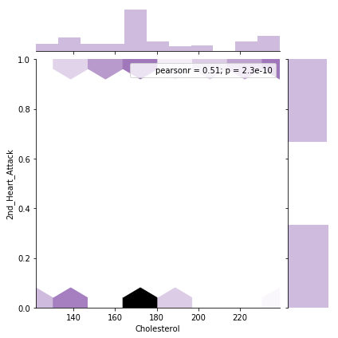

```python
sns.jointplot("Cholesterol", "2nd_Heart_Attack", df, kind="hex", color="#8855AA")
```

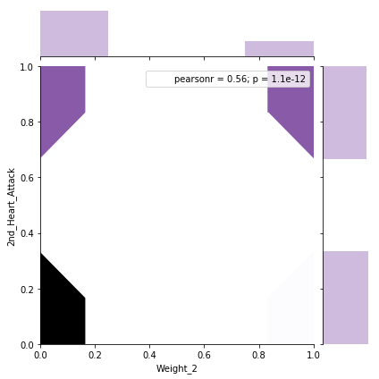

```python
sns.jointplot("Weight_2", "2nd_Heart_Attack", df, kind="hex", color="#8855AA")
```

# 2. What types of data transformation did you have to do for correlation analysis?

To transform the data, Yes and No were changed to 1 and 0, Gender was broken into categories and Marital status was changed into dummy variables.

# 3. Explain the results of the correlation analysis?

The strongest correlation was between weight and having a second heart attack. Those who weighed more had a higher chance of having a second heart attack.There is also a correlation between getting a divorce and having a second heart attack.

# 4. Describe the characteristics of people who are at risk of having 2nd heart attack.

People who are more at risk of having a second heart attack are

- older people
- overweight
- divorced
- high cholesterol

# 5. What is your general recommendation for the healthcare provider?

To help prevent people having 2nd heart attacks, a hospital should encourage it's clients to lose weight, avoid divorce(?!) and keep cholesterol levels at a healthy level

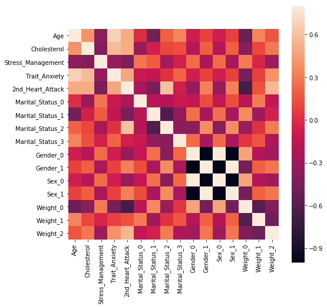

```python
plt.figure(figsize=(8,8))
sns.heatmap(df.corr(),vmax=.8, square=True)
```

# Who is more likely to cheat on a spouse

```python
df=pd.read_excel("data/affairs.xlsx")
print df.head()
```

```
   rate_marriage   age  yrs_married  children  religious  educ  occupation  \
0              3  32.0          9.0       3.0          3    17           2
1              3  27.0         13.0       3.0          1    14           3
2              4  22.0          2.5       0.0          1    16           3
3              4  37.0         16.5       4.0          3    16           5
4              5  27.0          9.0       1.0          1    14           3

   occupation_husb   affairs  affairs_yes_no
0                5  0.111111               1
1                4  3.230769               1
2                5  1.400000               1
3                5  0.727273               1
4                4  4.666666               1
```

```python
df.describe()
```

|  | rate_marriage | age | yrs_married | children | religious | educ | occupation | occupation_husb | affairs | affairs_yes_no |
| --- | --- | --- | --- | --- | --- | --- | --- | --- | --- | --- |
| count | 6366.000000 | 6366.000000 | 6366.000000 | 6366.000000 | 6366.000000 | 6366.000000 | 6366.000000 | 6366.000000 | 6366.000000 | 6366.000000 |
| mean | 4.109645 | 29.082862 | 9.009425 | 1.396874 | 2.426170 | 14.209865 | 3.424128 | 3.850141 | 0.705374 | 0.322495 |
| std | 0.961430 | 6.847882 | 7.280120 | 1.433471 | 0.878369 | 2.178003 | 0.942399 | 1.346435 | 2.203374 | 0.467468 |
| min | 1.000000 | 17.500000 | 0.500000 | 0.000000 | 1.000000 | 9.000000 | 1.000000 | 1.000000 | 0.000000 | 0.000000 |
| 25% | 4.000000 | 22.000000 | 2.500000 | 0.000000 | 2.000000 | 12.000000 | 3.000000 | 3.000000 | 0.000000 | 0.000000 |
| 50% | 4.000000 | 27.000000 | 6.000000 | 1.000000 | 2.000000 | 14.000000 | 3.000000 | 4.000000 | 0.000000 | 0.000000 |
| 75% | 5.000000 | 32.000000 | 16.500000 | 2.000000 | 3.000000 | 16.000000 | 4.000000 | 5.000000 | 0.484848 | 1.000000 |
| max | 5.000000 | 42.000000 | 23.000000 | 5.500000 | 4.000000 | 20.000000 | 6.000000 | 6.000000 | 57.599991 | 1.000000 |

```python
df.info()
```

```
<class 'pandas.core.frame.DataFrame'>
Int64Index: 6366 entries, 0 to 6365
Data columns (total 10 columns):
rate_marriage      6366 non-null int64
age                6366 non-null float64
yrs_married        6366 non-null float64
children           6366 non-null float64
religious          6366 non-null int64
educ               6366 non-null int64
occupation         6366 non-null int64
occupation_husb    6366 non-null int64
affairs            6366 non-null float64
affairs_yes_no     6366 non-null int64
dtypes: float64(4), int64(6)
memory usage: 547.1 KB
```

```python
df.groupby('affairs_yes_no').count()
```

| affairs_yes_no | rate_marriage | age | yrs_married | children | religious | educ | occupation | occupation_husb | affairs |
| --- | --- | --- | --- | --- | --- | --- | --- | --- | --- |
| 0 | 4313 | 4313 | 4313 | 4313 | 4313 | 4313 | 4313 | 4313 | 4313 |
| 1 | 2053 | 2053 | 2053 | 2053 | 2053 | 2053 | 2053 | 2053 | 2053 |

# 6. How many people had affairs? How many didn’t?

- out of 6366 people polled, 2053 had an affair and 4313 did not

```python
df.groupby(['affairs_yes_no','religious']).count()
```

| affairs_yes_no | religious | rate_marriage | age | yrs_married | children | educ | occupation | occupation_husb | affairs |
| --- | --- | --- | --- | --- | --- | --- | --- | --- | --- |
| 0 | 1 | 613 | 613 | 613 | 613 | 613 | 613 | 613 | 613 |
|  | 2 | 1448 | 1448 | 1448 | 1448 | 1448 | 1448 | 1448 | 1448 |
|  | 3 | 1715 | 1715 | 1715 | 1715 | 1715 | 1715 | 1715 | 1715 |
|  | 4 | 537 | 537 | 537 | 537 | 537 | 537 | 537 | 537 |
| 1 | 1 | 408 | 408 | 408 | 408 | 408 | 408 | 408 | 408 |
|  | 2 | 819 | 819 | 819 | 819 | 819 | 819 | 819 | 819 |
|  | 3 | 707 | 707 | 707 | 707 | 707 | 707 | 707 | 707 |
|  | 4 | 119 | 119 | 119 | 119 | 119 | 119 | 119 | 119 |

```python
df.groupby(['affairs_yes_no','age']).count()
```

| affairs_yes_no | age | rate_marriage | yrs_married | children | religious | educ | occupation | occupation_husb | affairs |
| --- | --- | --- | --- | --- | --- | --- | --- | --- | --- |
| 0 | 17.5 | 126 | 126 | 126 | 126 | 126 | 126 | 126 | 126 |
|  | 22.0 | 1394 | 1394 | 1394 | 1394 | 1394 | 1394 | 1394 | 1394 |
|  | 27.0 | 1298 | 1298 | 1298 | 1298 | 1298 | 1298 | 1298 | 1298 |
|  | 32.0 | 644 | 644 | 644 | 644 | 644 | 644 | 644 | 644 |
|  | 37.0 | 364 | 364 | 364 | 364 | 364 | 364 | 364 | 364 |
|  | 42.0 | 487 | 487 | 487 | 487 | 487 | 487 | 487 | 487 |
| 1 | 17.5 | 13 | 13 | 13 | 13 | 13 | 13 | 13 | 13 |
|  | 22.0 | 406 | 406 | 406 | 406 | 406 | 406 | 406 | 406 |
|  | 27.0 | 633 | 633 | 633 | 633 | 633 | 633 | 633 | 633 |
|  | 32.0 | 425 | 425 | 425 | 425 | 425 | 425 | 425 | 425 |
|  | 37.0 | 270 | 270 | 270 | 270 | 270 | 270 | 270 | 270 |
|  | 42.0 | 306 | 306 | 306 | 306 | 306 | 306 | 306 | 306 |

```python
df.groupby(['affairs_yes_no','educ']).count()
```

| affairs_yes_no | educ | rate_marriage | age | yrs_married | children | religious | occupation | occupation_husb | affairs |
| --- | --- | --- | --- | --- | --- | --- | --- | --- | --- |
| 0 | 9 | 27 | 27 | 27 | 27 | 27 | 27 | 27 | 27 |
|  | 12 | 1361 | 1361 | 1361 | 1361 | 1361 | 1361 | 1361 | 1361 |
|  | 14 | 1469 | 1469 | 1469 | 1469 | 1469 | 1469 | 1469 | 1469 |
|  | 16 | 844 | 844 | 844 | 844 | 844 | 844 | 844 | 844 |
|  | 17 | 370 | 370 | 370 | 370 | 370 | 370 | 370 | 370 |
|  | 20 | 242 | 242 | 242 | 242 | 242 | 242 | 242 | 242 |
| 1 | 9 | 21 | 21 | 21 | 21 | 21 | 21 | 21 | 21 |
|  | 12 | 723 | 723 | 723 | 723 | 723 | 723 | 723 | 723 |
|  | 14 | 808 | 808 | 808 | 808 | 808 | 808 | 808 | 808 |
|  | 16 | 273 | 273 | 273 | 273 | 273 | 273 | 273 | 273 |
|  | 17 | 140 | 140 | 140 | 140 | 140 | 140 | 140 | 140 |
|  | 20 | 88 | 88 | 88 | 88 | 88 | 88 | 88 | 88 |

```python
df.groupby(['affairs_yes_no','children']).count()
```

| affairs_yes_no | children | rate_marriage | age | yrs_married | religious | educ | occupation | occupation_husb | affairs |
| --- | --- | --- | --- | --- | --- | --- | --- | --- | --- |
| 0 | 0.0 | 1912 | 1912 | 1912 | 1912 | 1912 | 1912 | 1912 | 1912 |
|  | 1.0 | 747 | 747 | 747 | 747 | 747 | 747 | 747 | 747 |
|  | 2.0 | 873 | 873 | 873 | 873 | 873 | 873 | 873 | 873 |
|  | 3.0 | 460 | 460 | 460 | 460 | 460 | 460 | 460 | 460 |
|  | 4.0 | 197 | 197 | 197 | 197 | 197 | 197 | 197 | 197 |
|  | 5.5 | 124 | 124 | 124 | 124 | 124 | 124 | 124 | 124 |
| 1 | 0.0 | 502 | 502 | 502 | 502 | 502 | 502 | 502 | 502 |
|  | 1.0 | 412 | 412 | 412 | 412 | 412 | 412 | 412 | 412 |
|  | 2.0 | 608 | 608 | 608 | 608 | 608 | 608 | 608 | 608 |
|  | 3.0 | 321 | 321 | 321 | 321 | 321 | 321 | 321 | 321 |
|  | 4.0 | 131 | 131 | 131 | 131 | 131 | 131 | 131 | 131 |
|  | 5.5 | 79 | 79 | 79 | 79 | 79 | 79 | 79 | 79 |

```python
df.groupby(['affairs_yes_no','yrs_married']).count()
```

| affairs_yes_no | yrs_married | rate_marriage | age | children | religious | educ | occupation | occupation_husb | affairs |
| --- | --- | --- | --- | --- | --- | --- | --- | --- | --- |
| 0 | 0.5 | 354 | 354 | 354 | 354 | 354 | 354 | 354 | 354 |
|  | 2.5 | 1595 | 1595 | 1595 | 1595 | 1595 | 1595 | 1595 | 1595 |
|  | 6.0 | 754 | 754 | 754 | 754 | 754 | 754 | 754 | 754 |
|  | 9.0 | 348 | 348 | 348 | 348 | 348 | 348 | 348 | 348 |
|  | 13.0 | 347 | 347 | 347 | 347 | 347 | 347 | 347 | 347 |
|  | 16.5 | 449 | 449 | 449 | 449 | 449 | 449 | 449 | 449 |
|  | 23.0 | 466 | 466 | 466 | 466 | 466 | 466 | 466 | 466 |
| 1 | 0.5 | 16 | 16 | 16 | 16 | 16 | 16 | 16 | 16 |
|  | 2.5 | 439 | 439 | 439 | 439 | 439 | 439 | 439 | 439 |
|  | 6.0 | 387 | 387 | 387 | 387 | 387 | 387 | 387 | 387 |
|  | 9.0 | 254 | 254 | 254 | 254 | 254 | 254 | 254 | 254 |
|  | 13.0 | 243 | 243 | 243 | 243 | 243 | 243 | 243 | 243 |
|  | 16.5 | 369 | 369 | 369 | 369 | 369 | 369 | 369 | 369 |
|  | 23.0 | 345 | 345 | 345 | 345 | 345 | 345 | 345 | 345 |

# 7. What are some general findings from groupby? What are some general characteristics of those having affairs in terms of rate_marriage, age, yrs_married, children, religious, and educ.

- more kids cause a higher rate of affairs
- longer they were married the higher the rate of affair
- less education has higher rates of affairs
- rates of affairs go up over age

# 8. Is there a statistical difference between those having affairs and those don’t in terms of religious devotion? Explain the relationship between religious devotion and affairs

Yes, Those who are more religious tend to cheat on their spouse less

# 9. Is there a statistical difference between those having affairs and those don’t in terms of rate_marriage? Explain the relationship between rate_marriage and affairs

```python
df.groupby(['affairs_yes_no','rate_marriage']).count()
```

| affairs_yes_no | rate_marriage | age | yrs_married | children | religious | educ | occupation | occupation_husb | affairs |
| --- | --- | --- | --- | --- | --- | --- | --- | --- | --- |
| 0 | 1 | 25 | 25 | 25 | 25 | 25 | 25 | 25 | 25 |
|  | 2 | 127 | 127 | 127 | 127 | 127 | 127 | 127 | 127 |
|  | 3 | 446 | 446 | 446 | 446 | 446 | 446 | 446 | 446 |
|  | 4 | 1518 | 1518 | 1518 | 1518 | 1518 | 1518 | 1518 | 1518 |
|  | 5 | 2197 | 2197 | 2197 | 2197 | 2197 | 2197 | 2197 | 2197 |
| 1 | 1 | 74 | 74 | 74 | 74 | 74 | 74 | 74 | 74 |
|  | 2 | 221 | 221 | 221 | 221 | 221 | 221 | 221 | 221 |
|  | 3 | 547 | 547 | 547 | 547 | 547 | 547 | 547 | 547 |
|  | 4 | 724 | 724 | 724 | 724 | 724 | 724 | 724 | 724 |
|  | 5 | 487 | 487 | 487 | 487 | 487 | 487 | 487 | 487 |

Yes, those who reported their marriage lower had much higher rates of affair than those who were happy in their marriage

# 10. Is there a statistical difference between those having affairs and those don’t in terms of age? Explain the relationship between age and affairs

As couples get older, statistically the rate of affairs goes up. Younger people have a much lower rate of affairs in marriage

```python
import pandas as pd
import numpy as np
from scipy import stats
from pandas.tools import plotting
import matplotlib.pyplot as plt
%matplotlib inline

import scipy.stats as stats
```

```python
results = stats.ttest_rel(df['religious'], df['affairs_yes_no'])
print "The t-statistic is %.3f and the p-value is %.3f." % results
```

```
The t-statistic is 160.309 and the p-value is 0.000.
```

# 11. Explain how you use p-value in t-test

- P-value is used to show the relationship between two variables and see if there is a correlation. The closer to 0 the closer the correlation

# 12. Your own question & findings

## Is there a correlation to the occupation of the husband and divorce rates?

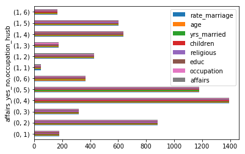

```python
df.groupby(['affairs_yes_no','occupation_husb']).count().plot(kind='barh')
```

## there does appear to be a correlation between different job fields